# BPB3: BayesPI-BAR version 3 package User Guide

# Demo4:

# Applying bpb3 on Genome-wide Sequencing Data of Follicular Lymphoma Patients by using clustered-PWMs

demo4_fl_cohort_small_cluster4pwm

## Aim and pipeline flow

Similar to demo3, the current demo intendeds to predict TF binding affinity changes that are significantly altered by mutations in follicular lymphoma (FL) patients, by considering both the genome-wide sequencing data and the RNA-seq data of gene expressions. However, there is a difference in the input PWMs: for demo3, we used ~1772 human PWMs collected from various source for the prediction; but for demo4, ~737 clustered PWMs, which generated by applying abc4pwm ([reference to Omer 2022 paper](https://bmcbioinformatics.biomedcentral.com/articles/10.1186/s12859-022-04615-z?target=_blank)) package on the ~1772 human PMWs, are used in the calculation. In other words, the three main steps of the significance test for TF-DNA binding affinity changes in demo4 are all based on ~737 clustered PWMs. It suggests that the overall computational speed will be significantly reduced (e.g., 79 and 37 minutes for demo3 and demo4, respectively) if the same prediction pipeline is applied on a large number of mutation blocks.

## Run job

**run job**  
demo4_fl_cohort_small_cluster4pwm/sbatch job_bpb3

```bash
sbatch job_bpb3
```

Job script: demo4_fl_cohort_small_cluster4pwm/job_bpb3

```bash
#!/bin/csh

#Job name:
#SBATCH --job-name=demo4-bpb3-flC
#
# Project:
#SBATCH --account=nn4605k
#
# Wall clock limit:
#SBATCH --time=12:00:00
#
# Max memory usage:
#SBATCH --mem-per-cpu=12G
###--partition=bigmem
#
# Number of cores:
#SBATCH --cpus-per-task=12

bpb3 run_pipeline --import_bpb3_config bpb3_clusterPWM_config_fl.py
```

**Main process** The main processes are stored in Slurm file, example:

```
T-test
Export at  bpb3/final_demo_data/demo4_fl_cohort_small_cluster4pwm/out/regions.bed
Read bpb3/final_demo_data/demo4_fl_cohort_small_cluster4pwm/out/mussd_blocks/blocks_summary.tsv
Adjust P-values by Bonferroni correction in high mutation blocks test
Background block size will be equal to median significant block size: 611

Mutation count distribution:
     number of mutations     probability
     3   0.058823529411764705
     4   0.11764705882352941
     5   0.11764705882352941

202 PWMs are chosen for background model based on foreground rankings (max rank is 20 )
bpb3/final_demo_data/demo4_fl_cohort_small_cluster4pwm/out/pwm_for_background bpb3_package/bpb3/final_demo_data/demo4_fl_cohort_small_cluster4pwm/out/../tmp_pwm

Running BayesPI-BAR to compute background affinity changes.

Calculating dbA values
Integrating delta-dbA values across chemical potentials using mean_ddba ...
Computing PWM rankings for each variant...

Positive PWMs at 0.05 bonferroni significance:
     abc4pwm_uncertain_pwms~8_ZNF219_1_from_ZNF219_transfac_M01122-C2H2_ZF.mlp  bonferroni p: 0.014237621403183074  #cases: 8 / 8
Negative PWMs at 0.05 bonferroni significance:
     abc4pwm_quality_assessed_out_seed5~Homeodomain~out~32~repres~32_rep.mlp    bonferroni p: 4.265850011473182e-06     #cases: 7 / 8

Add path
 bpb3_package/bpb3/final_demo/demo4_fl_cohort_small_cluster4pwm
"import bpb3_clusterPWM_config_fl as bpb3_config"

block_0_18_60986372_60987028 :
block_1_18_60987833_60988302 :
Filtering results by gene expression for block block_0_18_60986372_60987028 ...
Filtering results by gene expression for block block_1_18_60987833_60988302 ...
```

**data input**

```
# Gene expression data of control samples:
final_demo_data/demo4_fl_cohort_small_cluster4pwm/normal_gcb_counts/
|-- SRR834983.sorted.only_counts.tsv
|-- SRR834984.sorted.only_counts.tsv
|-- SRR834985.sorted.only_counts.tsv
`-- SRR834986.sorted.only_counts.tsv

# Patient specific mutations (vcf format) and gene expression data (*_expression.tsv)
final_demo_data/demo4_fl_cohort_small_cluster4pwm/patient_data/
|-- DO27859
|   |-- DO27859_expression.tsv
|   `-- icgc_mutations_on_18.tsv
|-- DO52653
|   |-- DO52653_expression.tsv
|   `-- icgc_mutations_on_18.tsv
|-- DO52656
|-- DO52669
|-- DO52676
|-- DO52677
|-- DO52680
|-- DO52681
|-- DO52685
|-- DO52689
|-- DO52694

# Clustered PWMs by applying abc4pwm on 1772 human PWMs when considering DNA binding domain (DBE) information:
final_demo_data/demo4_fl_cohort_small_cluster4pwm/abc4pwm_quality_assessed_out_seed5/
├── A.T_hook_factors
├── ARID_domain_factors
├── C2CH_THAP_type_ZF
│   └── out
│       ├── 0
│       │   ├── 0_AP1_known1_from_AP1_2_from_AP-1_transfac_M00172-C2CH_THAP_type_ZF.mlp
│       │   ├── 0_AP1_known2_from_AP1_3_from_AP-1_transfac_M00173-C2CH_THAP_type_ZF.mlp
│       │   ├── 0_AP1_known4_from_AP1_5_from_AP-1_transfac_M00188-C2CH_THAP_type_ZF.mlp
│       │   └── repres
│       │       └── 0_rep.mlp
│       ├── 1
│       │   ├── 1_AP1_known10_from_AP1_1_from_AP1_jaspar_MA0099.2-C2CH_THAP_type_ZF.mlp
│       │   ├── 1_AP1_known7_from_AP1_8_from_AP-1_transfac_M00924-C2CH_THAP_type_ZF.mlp
│       │   ├── 1_AP1_known9_from_AP1_10_from_AP-1_transfac_M00926-C2CH_THAP_type_ZF.mlp
│       │   └── repres
│       │       └── 1_rep.mlp
│       ├── 2
│       │   ├── 2_AP1_known5_from_AP1_6_from_AP-1_transfac_M00199-C2CH_THAP_type_ZF.mlp
│       │   ├── 2_AP1_known8_from_AP1_9_from_AP-1_transfac_M00925-C2CH_THAP_type_ZF.mlp
 ...

# If PWMs with low cluster quality scores based on abc4pwm, then they are grouped in a folder labeled as uncertain_pwm:
final_demo_data/demo4_fl_cohort_small_cluster4pwm/abc4pwm_uncertain_pwms/
├── 0_AP1_known3_from_AP1_4_from_AP-1_transfac_M00174-C2CH_THAP_type_ZF.mlp
├── 0_ARHGEF12_1_from_IRC900814_bulyk_sc09-primary-Unknown.mlp
├── 0_BPTF_1_from_FAC1_transfac_M00456-Unknown.mlp
├── 0_BRCA1_known1_from_BRCA1_1_from_BRCA1:USF2_transfac_M01082-Unknown.mlp
├── 0_COMP1_1_from_COMP1_transfac_M00057-Unknown.mlp
 ...
```

**data output**

```
# The final results for each mutation block are stored in folder “foreground/block_id”:

final_demo_data/demo4_fl_cohort_small_cluster4pwm/out/
|-- background
|   |-- background_mutation_pos.bed
|   |-- bayespi_bar_result
|   |-- possible_background_blocks_restricted.bed
|   |-- possible_background_block_starts.bed
|   |-- randomly_selected_blocks_alt.fasta
|   |-- randomly_selected_blocks.bed
|   `-- randomly_selected_blocks_ref.fasta
|-- demo4_fl_cohort_smallcluster4pwm_bpb3.log_1654257475.5522199
|-- demo4_fl_cohort_smallcluster4pwm_bpb3.log_1655212056.4320252
|-- differentially_expressed_genes.txt
|-- foreground
|   |-- block_0_18_60986372_60987028
|   `-- block_1_18_60987833_60988302
|-- make_background.sh
|-- mussd_blocks
|   |-- block_0_18_60986372_60987028_alt.fasta
|   |-- block_0_18_60986372_60987028.bed
|   |-- block_0_18_60986372_60987028_mutations.tsv
|   |-- block_0_18_60986372_60987028_ref.fasta
|   |-- block_1_18_60987833_60988302_alt.fasta
|   |-- block_1_18_60987833_60988302.bed
|   |-- block_1_18_60987833_60988302_mutations.tsv
|   |-- block_1_18_60987833_60988302_ref.fasta
|   |-- blocks_summary.tsv
|   |-- mutations_in_regions.tsv
|   |-- mutations_summary.tsv
|   `-- patients_summary.tsv
|-- normal_median_patient_rpkm.tsv
|-- regions.bed
|-- run_mussd.sh
|-- significant_blocks.txt
`-- tumor_median_patient_rpkm.tsv
```

**Table 1**: One example of final results from bpb3 when using clustered PWMs to predict TFs bind affinity changes at promoter regions of differential expressed genes (DEG). (final_demo_data/demo4_fl_cohort_small_cluster4pwm/out/foreground/block_1_18_60987833_60988302/result_filtered.tsv)

| direction | pwm_name | bonferroni_p | affected_cases | total_cases |
| --- | --- | --- | --- | --- |
| Negative | abc4pwm_quality_assessed_out_seed5<sub>SMAD</sub>out<sub>2</sub>repres~2_rep.mlp | 0.0000030 | 8 | 9 |
| Negative | abc4pwm_uncertain_pwms~16_FOXL1_4_from_FOXL1_jolma_full_M423-Forkhead.mlp | 0.0059908 | 8 | 9 |
| Negative | abc4pwm_uncertain_pwms~48_MEIS2_4_from_Meis2_jolma_DBD_M168-Homeodomain.mlp | 0.0070089 | 8 | 9 |
| Negative | abc4pwm_uncertain_pwms~48_MEIS3_3_from_MEIS3_jolma_DBD_M166-Homeodomain.mlp | 0.0095602 | 8 | 9 |
| Negative | abc4pwm_uncertain_pwms~32_ZEB1_known1_from_ZEB1_1_from_AREB6_transfac_M00412-Homeodomain.mlp | 0.0259287 | 8 | 9 |
| Negative | abc4pwm_uncertain_pwms~6_NFE2L2_2_from_Nrf-2_transfac_M00821-bZIP.mlp | 0.0493618 | 7 | 9 |

**Output of predicted TFs with significant binding affinity changes due to mutation block**

File in: final_demo_data/demo4_fl_cohort_small_cluster4pwm/out/foreground/block_1_18_60987833_60988302/result_plot.png

Here, a heatmap plot (result_plot.png) of TF binding affinity changes (either positive – orange color or negative-purple color) in Table 1 is illustrated. This figure shows top ranked TFs with significant binding affinity changes due to a mutation block (block_1_18_60987833_60988302) located at promoter of a differentially expressed BCL2 gene. The binding affinity of several transcript factors, including FOXL1 and MEIS2/3, are negatively affected by this mutation block in most of patients. These results are similar to the original publication [Batmanove 2017 Sci Reprots paper](https://www.nature.com/articles/s41598-017-07226-4?target=_blank) when original 1772 human PWMs were used in the predication. Nevertheless, no TF with positive binding affinity change is predicted by the clustered PWM. Thus, bpb3 with clustered PWMs approach can be used as a quick exploration method for a large number of mutation blocks.

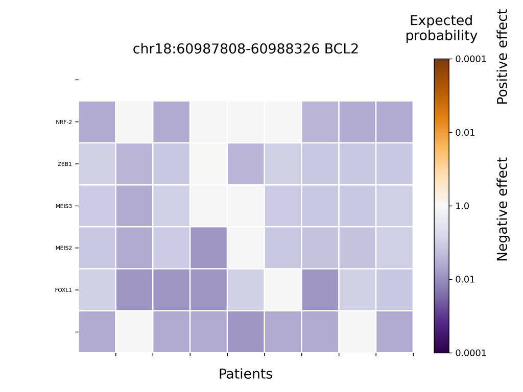

**Figure 1. result_plot**

**output of mutation block sequence**  
patients: out/mussd_blocks/block_1_18_60987833_60988302_alt.fasta  
reference: out/mussd_blocks/block_1_18_60987833_60988302_ref.fasta

Here is an alignment of mutation block with reference sequence and view a phylogram tree by pasting above sequence into [Clustal Omega](https://www.ebi.ac.uk/Tools/msa/clustalo/). Figure 2 shows the mutation positions in 9 patients compared to reference genome (health control). High mutation frequency occurred in this mutation block from patients, with about 60 point mutations in total.

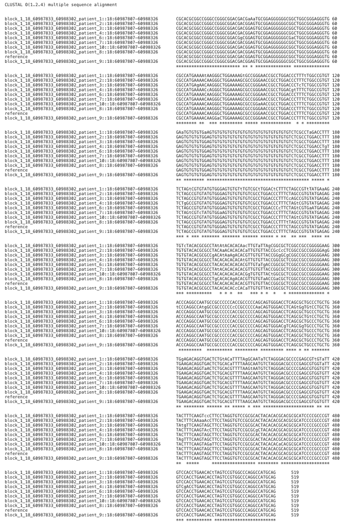

**Figure 2. Sequence alignment for patient specific mutation blocks**

Figure 3 showing the distance of patients from health control (reference) based on the sequence similarity generated by [Clustal Omega](https://www.ebi.ac.uk/Tools/msa/clustalo/?target=_blank) . Most of the patients display distance away from reference except patient_9, supporting that this region is a mutation hot block among patients.

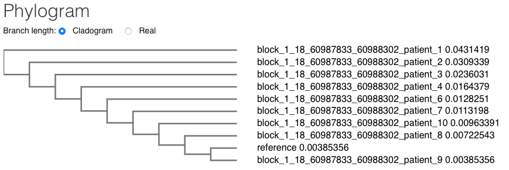

**Figure 3. Phylogram tree of mutation block**

**CPU requirement**

- MaxRSS: 78 MB
- Running time: 37 min

## Python code

bpb3_clusterPWM_config_fl.py

This is a bpb3 configure file, where input/output and other bpb3 pipeline parameters can be easily modified by users. This configure file can be directly upload by “bpb3 run_pipeline” command to run the whole BayesPI-BAR2 pipeline, [reference to Batmanov 2019 Front in Genet paper](https://www.frontiersin.org/articles/10.3389/fgene.2019.00282/full?target=_blank), for predicting TFs with significant binding affinity changes due to patient specific mutations.

```python
#This bpb3 parameter configure is for demo purpose
import os
import glob
from bpb3.script.script_high.other import common
import time

###########Setup main Paths and folders ################
#Project main Output path
out_data_folder = os.path.abspath("../../final_demo_data/demo4_fl_cohort_small_cluster4pwm/out")

#Project input path for patient mutation data and gene expression data
patient_data_folder = os.path.join(out_data_folder,'../', "patient_data")

#Project input path for gene expression data of normal control samples
normal_rnaseq_folder = os.path.join(out_data_folder,'../', "normal_gcb_counts")

#Project name in logo file
project_name='demo4_fl_cohort_smallcluster4pwm'

#Input Genome path
genome_folder=os.path.abspath("../../final_demo_data/genome_data/hg19/")

#Input human genome sequence
genome_fasta_file= os.path.join(genome_folder, "human_g1k_v37_decoy.fasta")

#Input gtf file of human genes from GenCode
gene_annotation_file= os.path.join(genome_folder, "gencode.v19.annotation.gtf")

#Project output folders for foreground and background calculations
foreground_folder = os.path.join(out_data_folder, "foreground")
background_folder = os.path.join(out_data_folder, "background")

#Background pwm folder
background_pwm_folder = os.path.join(out_data_folder, "pwm_for_background")

#output folder of predicted muation blocks by MUSSD algorithm
mussd_result_folder = os.path.join(out_data_folder, "mussd_blocks")

##### Set up input file name postprefix #########
#Input gene expression folder is located in patient data folder
#postprefix of gene expression file name for normal control samples such as files in folder normal_rnaseq_folder
normal_count_files_postprefix="*.only_counts.tsv"

#gene length file name
gene_length_file = os.path.join(genome_folder, "gene_lengths.tsv")

#postprefix of gene expression file name for patients such as files in folder patient_data_folder
donor_count_files_postprefix="D*/*_expression.tsv"

#### 0. set up PWM file path for clustered PWMs or common PWMs
##################Here is the only difference if input PWMs are either clustered PWMs or common PWMs! ################
################# Generate tempary pwms based on clustered and uncertain clustered PWMs ############
#Input path of clustered PWMs
in_clustered_pwms_path=os.path.join(out_data_folder,'../')

# file folder of clustered PWMs passed quality control in abc4pwm package
in_clustered_pwms_folder_name='abc4pwm_quality_assessed_out_seed5'

# file folder of PWMs do not pass quality control in abc4pwm
in_uncertain_pwms_folder_name='abc4pwm_uncertain_pwms'

# new input folder of clustered PWMs when reorganizing PWMs file names based on the two aforementioned folders.
# these renamed PWMs will be used as input PWMs for applying clustered  PWMs in bpb3
out_tmp_pwms_folder_name='tmp_pwm'

# final pwm folder path for TF binding affinity calculation.
# if we do not use clustered PWMs as input, then this can be simply replaced by a folder path of common PWMs such as the folder contains 1772 PWMs in bpb3
pwm_folder=os.path.join(in_clustered_pwms_path,out_tmp_pwms_folder_name)

###########Setup Pipeline parameters from step 1 to step 8 before running bpb3 #########
#### 1. Differential gene expression options
#export file name for differentially expressed genes
differentially_expressed_genes_file = os.path.join(out_data_folder, "differentially_expressed_genes.txt")

#group name for tumor and normal samples
group1_str='tumor'
group2_str='normal'
#Export gene expression files path
group1_median_rpkm_file = os.path.join(out_data_folder, group1_str + "_median_patient_rpkm.tsv")
group2_median_rpkm_file = os.path.join(out_data_folder, group2_str +"_median_patient_rpkm.tsv")

# maximum Kolmogorov-Smirnov test or other statistic test P value to consider genes as differentially expressed
differential_expression_p = 0.05
# whether to do quantile normalization of RPKM values, True or False
differential_expression_quantile_normalization = True
# whether to do log transformation of RPKM values, True or False
differential_expression_log_transform = True
# whether to do z-score transformation of RPKM values, True or False
differential_expression_z_score_transform = False
# minimum fold change of [quantile normalized] RPKM to consider genes as differentially expressed. None to disable
differential_expression_min_fold_change = None
#export full expression data , True or False
isExportAll = True
#select test method:  1 for T-test, 0 for KS-test
test_method=1
#minimum median RPKM allowed in each group, input 0 to disable this option
minimum_median_RPKM=0  #1.0

#### 2. Region of interest selection options
# number of base pairs to take upstream of TSS
upstream_size = 1000
# number of base pairs to take downstream of TSS
downstream_size = 1000
#Export file path for extracted regions
regions_file = os.path.join(out_data_folder, "regions.bed")

# If we do not use bpb3 function to extract a specified TSS regions, then manually input a bed format region file
# for example, using enhancer regions overlapping with Differential Methylation Regions for DNA muatation enrichment and the TF binding affinity change significance test
#regions_file='../demo7_mr_enhancers/in/dmr_intersect_enhancer_regions_chr18noChr_5kb_flank.tsv'

#### 3. MuSSD options
# minimum number of patients in a hot mutation region
min_patients_in_block = 3
# minimum number of mutations in a hot mutation region
min_block_size = 3
# maximum distance between mutations in a hot mutation region
cluster_distance = 30
# maximum distance between two adjacent mutaiton blocks
block_distance=500
# number of base pairs to add to the left and right side of a mutation block when extracting sequences
block_flank = 25

#### 4. P values for significant muation blocks
p_value_for_significant_blocks=0.001
#commamnd line file name for running mussd
mussd_command_file=os.path.join(out_data_folder, 'run_mussd.sh')
#whether to use bonferroni corrected p value, True or False
pval_correction=True

#patient mutation file names under folder patient_data_folder
patient_mut_files_postprefix="DO*/icgc_mutations*.tsv"

#Export file path of significant mutation blocks
significant_blocks_file = os.path.join(out_data_folder, "significant_blocks.txt")

#### 5. BayesPI-BAR options
# a range of chemical potentials to use
chemical_potentials = "none -10 -13 -15 -18 -20"
# sequence shuffling iterations for dbA calculation
shuffling_iterations = 10000
#Parallel option path
parallel_options_file = os.path.abspath(os.path.join(os.path.dirname(__file__), "parallel_options.txt"))
#maximum number of TFs will be ranked in foreground calculation
max_ranking_for_foreground=30
#whether both forground and background ddba are already exists, True or False
start_from_integration=False

#### 6. Background model options
# max rank of a PWM file in the foreground results to include in the background model
max_ranking_for_background = 20
# number of random resampling
resampling_iterations = 10
# number of genes will be sampled
gene_samples = 8
# number of random shuffling in backgroun calculation
background_shuffling_iterations = 1000
# command line file for running background calculation
background_command_file = os.path.join(out_data_folder, "make_background.sh")

#### 7. mutation signature definition for generating background mutations, set to None to disable
mutation_signature_file = None  # "../../data/signature_7.tsv"
# set to True to use tumor mutations from patients as background mutations, False otherwise.
# This and the mutation signature are mutually exclusive.
# In both are disabled, uniform mutations will be generated
tumor_mutations_as_background = True

# Results selection options for significant affinity changes
# P value for ranksum test in the output
affinity_change_p_value = 0.05
# whether to use bonferroni corrected p value, True or False
pval_correction4affinity=True
#signifcant block parameters, maximum number of top ranked PWMs
max_ranking_for_significant_blocks= 30

###### End of Parameter setup, below options for running each of the analysis pipeline in bpb3 ############
#### 8. Use True or False to either enable or disable the corresponding analysis step when running bpb3 #####

#step 1. differential expression analysis
runDiffExp= True

#step 2: region extraction
runRegionsFile= True

#step 3: mussd mutation block detection
runMussd= True

#step 4: highly mutated mutation block test
runHighMutBlocks= True

#step 5: do foreground bayespi-bar calculation
runBayesPiBAR= True

#step 6: do background bayespi-bar calcuation
runBackgroundModel= True

#step 7: do TF affinity change significance test
runBlockSignificance= True

#step 8: filter TF by gene expression level
filterTFbyGene=True

#step 9: plot heatmap for TFs with significaly changed binding affinity
isPlot=True

#step 10: remove temporary files in both foreground and background calculations
runRemoveTempFile= True

#option step: if the input PWMs are clustered PWMs from abc4pwm, then this option shall be True, otherwise it is False.
runCluster4PWM=True
```